# Pre-processament i anàlisi de dades.

# Exercici 2

## (a)

```r
setwd('.')
X <- read.table("PovertyStudy.dat",header = TRUE)
head(X)
```

|  | Birth | Death | Infant | LifeEM | LifeEF | GNP | Country |
| --- | --- | --- | --- | --- | --- | --- | --- |
| 1 | 24.7 | 5.7 | 30.8 | 69.6 | 75.5 | 600 | Albania |
| 2 | 12.5 | 11.9 | 14.4 | 68.3 | 74.7 | 2250 | Bulgaria |
| 3 | 13.4 | 11.7 | 11.3 | 71.8 | 77.7 | 2980 | Czechoslovakia |
| 4 | 12.0 | 12.4 | 7.6 | 69.8 | 75.9 | -99 | Former_E._Germany |
| 5 | 11.6 | 13.4 | 14.8 | 65.4 | 73.8 | 2780 | Hungary |
| 6 | 14.3 | 10.2 | 16.0 | 67.2 | 75.7 | 1690 | Poland |

```r
summary(X)
```

```
##      Birth           Death           Infant          LifeEM
##  Min.   : 9.70   Min.   : 2.20   Min.   :  4.5   Min.   :38.10
##  1st Qu.:14.50   1st Qu.: 7.80   1st Qu.: 13.1   1st Qu.:55.80
##  Median :29.00   Median : 9.50   Median : 43.0   Median :63.70
##  Mean   :29.23   Mean   :10.84   Mean   : 54.9   Mean   :61.49
##  3rd Qu.:42.20   3rd Qu.:12.50   3rd Qu.: 83.0   3rd Qu.:68.60
##  Max.   :52.20   Max.   :25.00   Max.   :181.6   Max.   :75.90
##
##      LifeEF           GNP               Country
##  Min.   :41.20   Min.   :  -99   Afghanistan: 1
##  1st Qu.:57.50   1st Qu.:  380   Albania    : 1
##  Median :67.80   Median : 1440   Algeria    : 1
##  Mean   :66.15   Mean   : 5380   Angola     : 1
##  3rd Qu.:75.40   3rd Qu.: 6340   Argentina  : 1
##  Max.   :81.80   Max.   :34064   Austria    : 1
##                                  (Other)    :91
```

## (b)

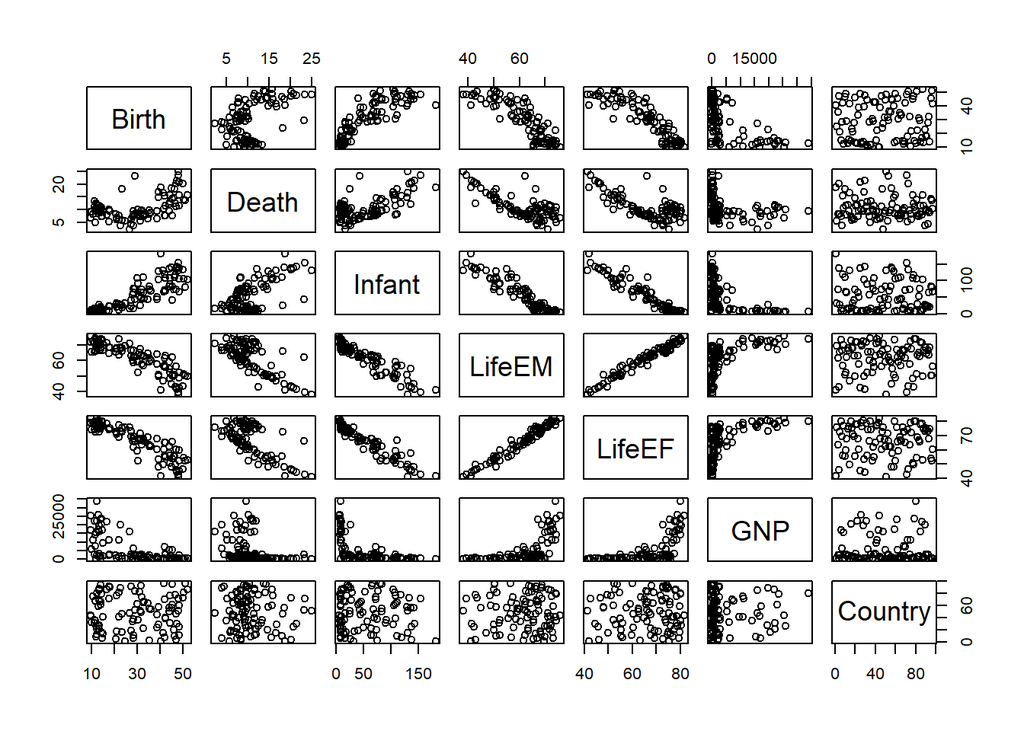

```r
pairs(X)
```

## (c)

```r
summary(X$GNP)
```

```
##    Min. 1st Qu.  Median    Mean 3rd Qu.    Max.
##     -99     380    1440    5380    6340   34064
```

```r
# són menys noranta-nous
sum(X$GNP == -99)
```

```
## [1] 6
```

Com podem veure en el `summary(X$GNP)`, hi ha valors codificats amb -99, que assumirem que són valors mancants. Així doncs, hi ha 6 països sense dades al GNP.

## (d)

```r
X$GNP[X$GNP ==-99] <- NA
summary(X$GNP)
```

```
##    Min. 1st Qu.  Median    Mean 3rd Qu.    Max.    NA's
##      80     475    1690    5741    7325   34064       6
```

## (e)

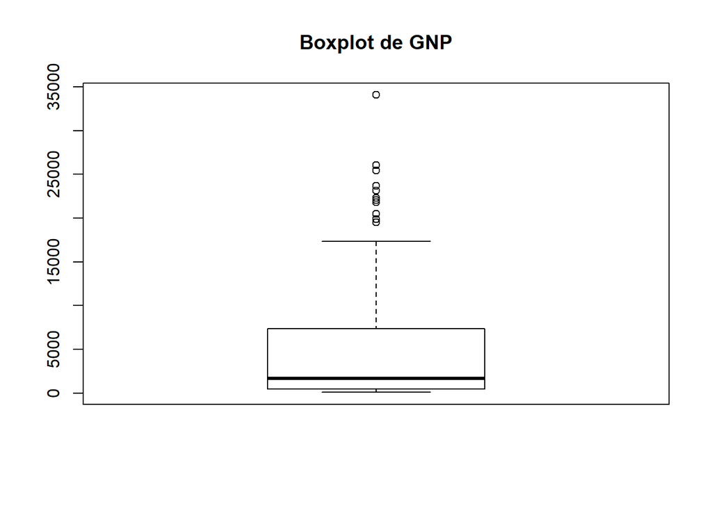

```r
boxplot(X$GNP, main = "Boxplot de GNP")
```

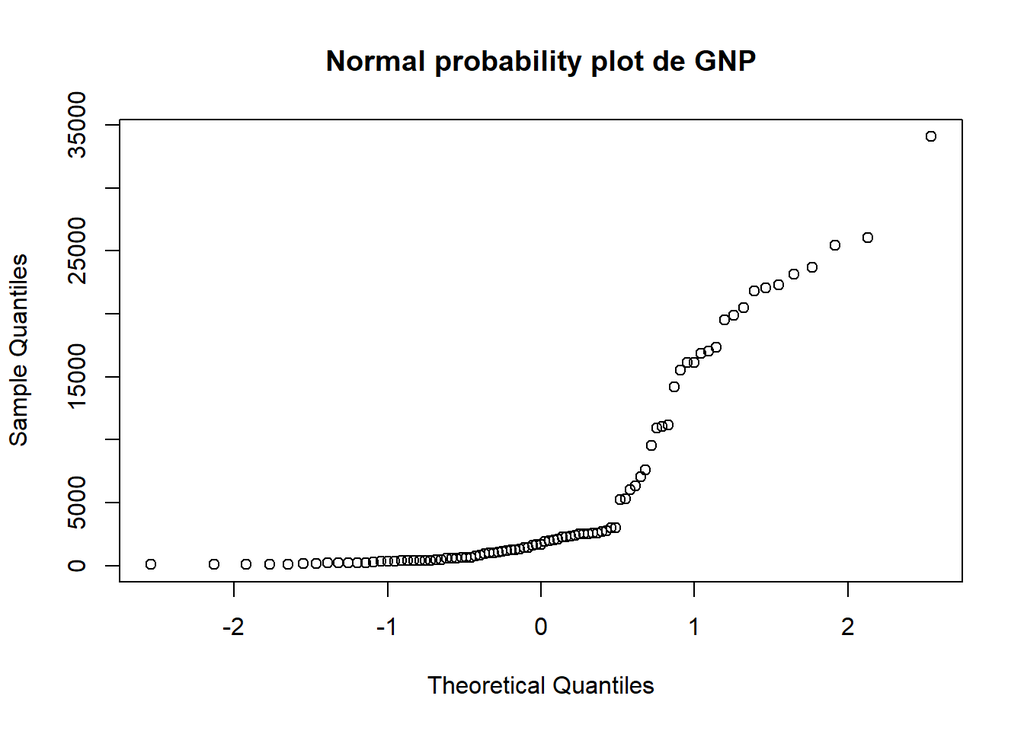

```r
qqnorm(X$GNP, main = "Normal probability plot de GNP")
```

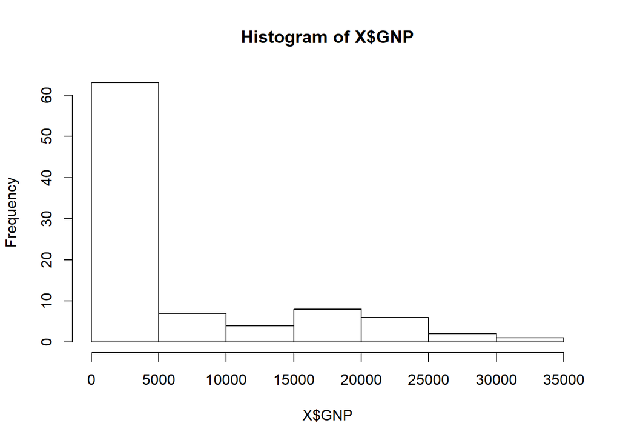

```r
hist(X$GNP)
```

Observem que la variable GNP no segueix una distribució normal, i que té diversos valors estranys (outliers). A més, el `qqnorm` no és lineal, ni tan sols s’hi apropa.

## (f)

```r
library(MASS)
b <- boxcox(X$GNP~1,lambda = seq(-1, 1, by = 0.1))
```

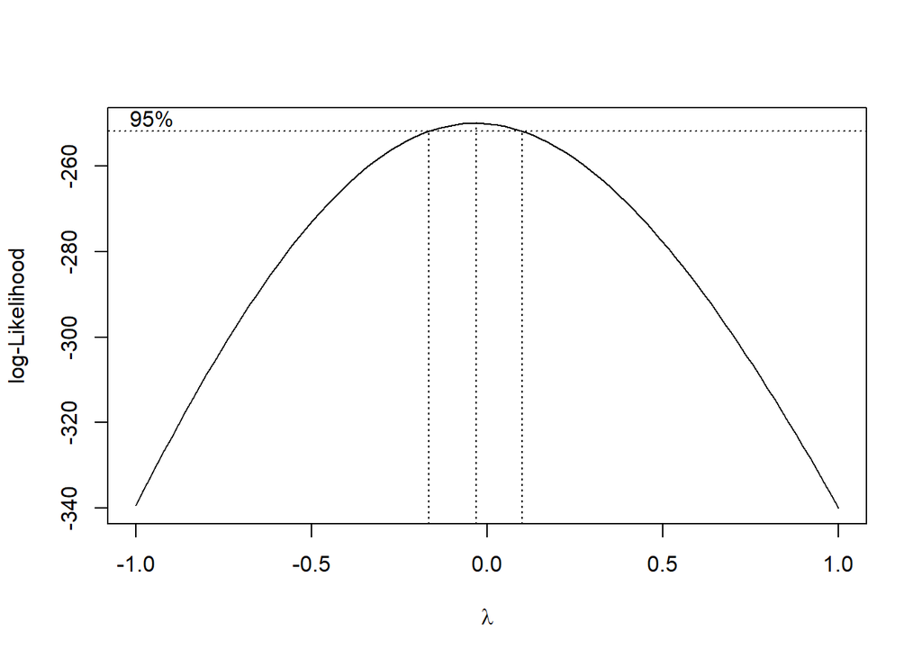

```r
(lambda <- b$x[which.max(b$y)])
```

```
## [1] -0.03030303
```

Cal fer una transformació de Box-Cox amb el paràmetre $\lambda\approx0$, que és pràcticament una transformació logarítmica.

## (g)

Primer transformem la variable per la transformació de Box-Cox:

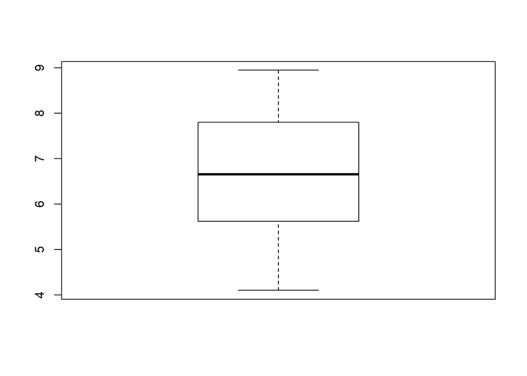

```r
transformed.GNP <- (X$GNP^lambda - 1) / lambda
boxplot(transformed.GNP)
```

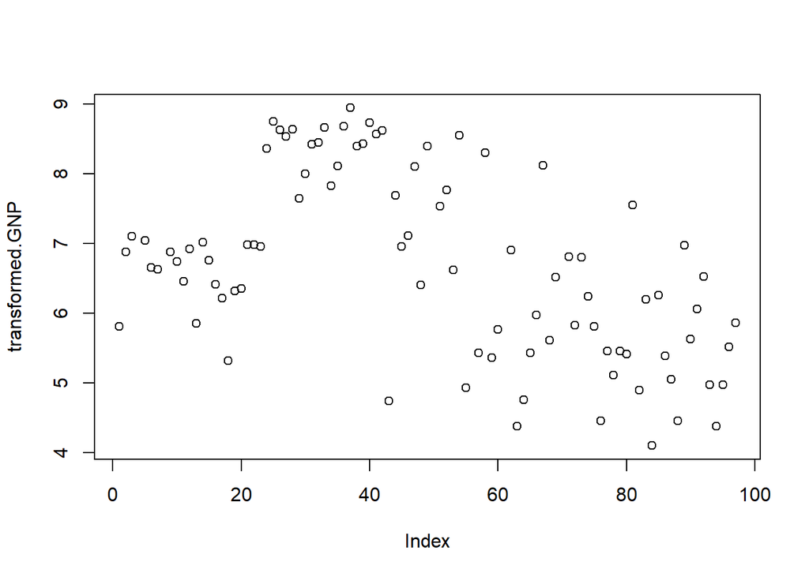

```r
plot(transformed.GNP)
```

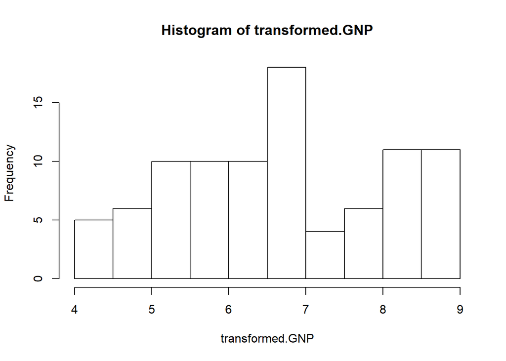

```r
hist(transformed.GNP)
```

La seva distribucio s’ha aproximat a una normal. Ara és una mica més simètrica que abans, i té menys valors estranys. Si ara ho provem pel logaritme,

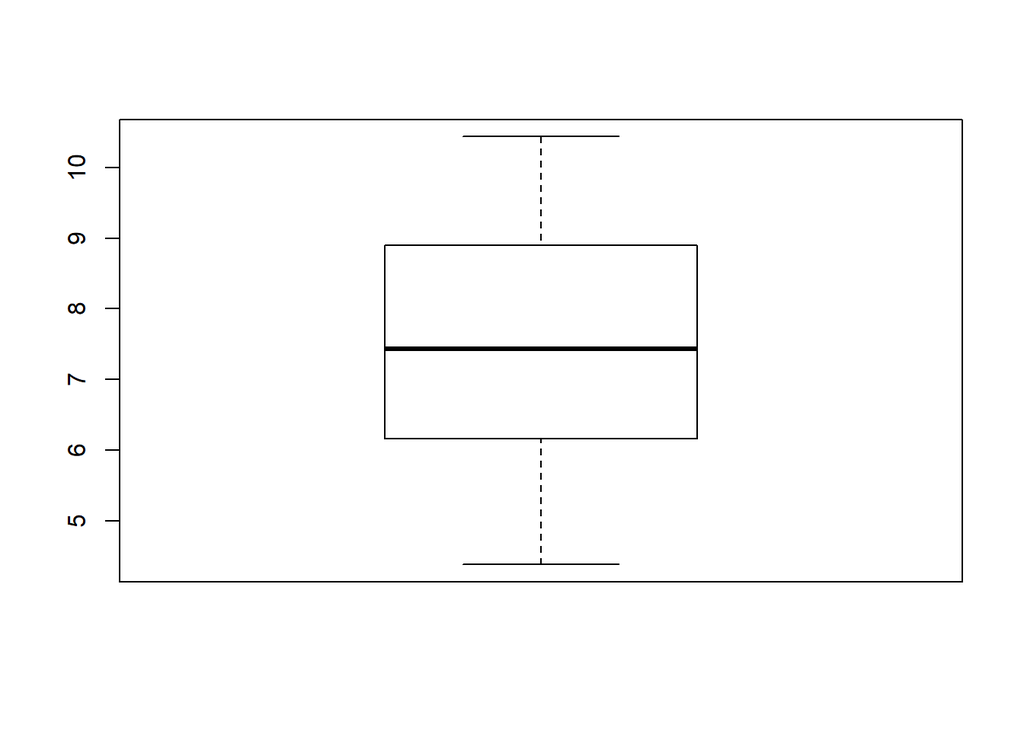

```r
log.GNP <- log(X$GNP)
boxplot(log.GNP)
```

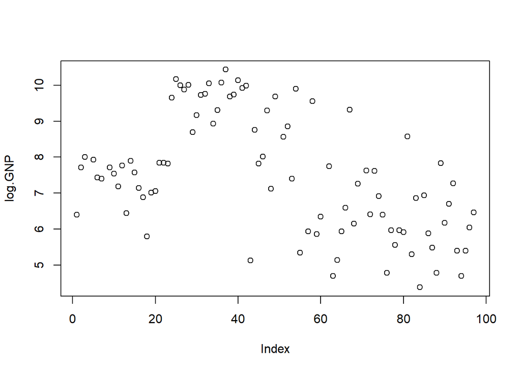

```r
plot(log.GNP)
```

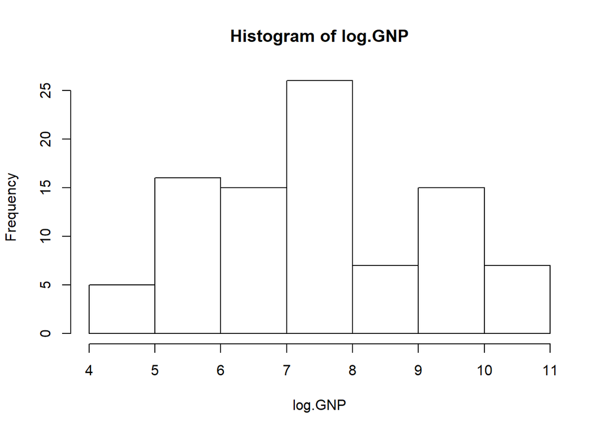

```r
hist(log.GNP)
```

## (h)

```r
X$GNPT <- transformed.GNP
X2 <- X[!is.na(X$GNPT),]
mod <- lm(GNPT ~ Birth + Death + Infant + LifeEM + LifeEF, X2)

summary(mod)
```

```
##
## Call:
## lm(formula = GNPT ~ Birth + Death + Infant + LifeEM + LifeEF,
##     data = X2)
##
## Residuals:
##      Min       1Q   Median       3Q      Max
## -1.89093 -0.49375  0.04469  0.50955  1.38844
##
## Coefficients:
##               Estimate Std. Error t value Pr(>|t|)
## (Intercept) -2.5376004  2.7404655  -0.926   0.3571
## Birth        0.0111321  0.0142214   0.783   0.4359
## Death        0.0481285  0.0286419   1.680   0.0966 .
## Infant       0.0002646  0.0056878   0.047   0.9630
## LifeEM       0.0258818  0.0466054   0.555   0.5801
## LifeEF       0.1026127  0.0482567   2.126   0.0364 *
## ---
## Signif. codes:  0 '***' 0.001 '**' 0.01 '*' 0.05 '.' 0.1 ' ' 1
##
## Residual standard error: 0.7468 on 85 degrees of freedom
## Multiple R-squared:  0.6922, Adjusted R-squared:  0.6741
## F-statistic: 38.23 on 5 and 85 DF,  p-value: < 2.2e-16
```

El model explica un 69.219554% de les dades del GNP.

## (i)

```r
X3 <- X[is.na(X$GNP),]
P <- predict(mod, newdata=X3)
X$GNPT[is.na(X$GNPT)] <- P
X[is.na(X$GNP),]
```

|  | Birth | Death | Infant | LifeEM | LifeEF | GNP | Country | GNPT |
| --- | --- | --- | --- | --- | --- | --- | --- | --- |
| 4 | 12.0 | 12.4 | 7.6 | 69.8 | 75.9 | NA | Former_E._Germany | 7.789641 |
| 8 | 14.0 | 9.0 | 20.2 | 68.6 | 74.5 | NA | Yugoslavia | 7.476886 |
| 50 | 31.7 | 8.7 | 48.0 | 63.1 | 67.0 | NA | Lebanon | 6.754896 |
| 56 | 41.4 | 16.6 | 130.0 | 47.0 | 49.9 | NA | Cambodia | 5.093416 |
| 61 | 23.5 | 18.1 | 25.0 | 66.2 | 72.7 | NA | Korea | 7.775062 |
| 70 | 31.8 | 9.5 | 64.0 | 63.7 | 67.9 | NA | Vietnam | 6.906627 |

## (j)

La variància dels residus del model és la suma de quadrats residual dividida entre els seus graus de llibertat. Aleshores,

```r
m0 <- lm(GNPT~1,X2)
(anv <- anova(mod))
```

|  | Df | Sum Sq | Mean Sq | F value | Pr(>F) |
| --- | --- | --- | --- | --- | --- |
| Birth | 1 | 83.412058 | 83.4120584 | 149.578266 | 1.967633e-20 |
| Death | 1 | 5.261354 | 5.2613540 | 9.434897 | 2.859466e-03 |
| Infant | 1 | 9.023794 | 9.0237938 | 16.181874 | 1.242409e-04 |
| LifeEM | 1 | 6.375462 | 6.3754622 | 11.432766 | 1.092226e-03 |
| LifeEF | 1 | 2.521429 | 2.5214294 | 4.521541 | 3.637033e-02 |
| Residuals | 85 | 47.400101 | 0.5576483 | NA | NA |

```r
s <- anv[6,2]/anv[6,1]
```

```r
set.seed(123)
(e <- rnorm(6, mean = 0, sd = sqrt(s)))
```

```
## [1] -0.41853995 -0.17188700  1.16397868  0.05265274  0.09654671  1.28073935
```

```r
#P + e
X$GNPT[is.na(X$GNP)] <- P + e
X[is.na(X$GNP),]
```

|  | Birth | Death | Infant | LifeEM | LifeEF | GNP | Country | GNPT |
| --- | --- | --- | --- | --- | --- | --- | --- | --- |
| 4 | 12.0 | 12.4 | 7.6 | 69.8 | 75.9 | NA | Former_E._Germany | 7.371101 |
| 8 | 14.0 | 9.0 | 20.2 | 68.6 | 74.5 | NA | Yugoslavia | 7.304999 |
| 50 | 31.7 | 8.7 | 48.0 | 63.1 | 67.0 | NA | Lebanon | 7.918875 |
| 56 | 41.4 | 16.6 | 130.0 | 47.0 | 49.9 | NA | Cambodia | 5.146069 |
| 61 | 23.5 | 18.1 | 25.0 | 66.2 | 72.7 | NA | Korea | 7.871608 |
| 70 | 31.8 | 9.5 | 64.0 | 63.7 | 67.9 | NA | Vietnam | 8.187366 |